# Portfolio 1: Analysis of Cycling Data

```python
import pandas as pd
import seaborn as sns
from matplotlib import pyplot as plt
from datetime import timedelta
import matplotlib.dates as mdates
from matplotlib.dates import DateFormatter
#plt.style.use('seaborn')
%matplotlib inline
```

## Loading Data

The first dataset is an export of my ride data from [Strava](https://strava.com/), an online social network site for cycling and other sports. This data is a log of every ride since the start of 2018 and contains summary data like the distance and average speed.

Read data from csv file and set index of the data frame to be the datetime of the ride.

```python
strava = pd.read_csv('data/strava_export.csv', index_col='date', parse_dates=True)
strava.index = strava.index.tz_localize('UTC')
strava.head()
```

| date | average_heartrate | average_temp | average_watts | device_watts | distance | elapsed_time | elevation_gain | kudos | moving_time | workout_type |
| --- | --- | --- | --- | --- | --- | --- | --- | --- | --- | --- |
| 2018-01-02 20:47:51+00:00 | 100.6 | 21.0 | 73.8 | False | 15.2 | 94 | 316.00 m | 10 | 73 | Ride |
| 2018-01-04 01:36:53+00:00 | NaN | 24.0 | 131.7 | False | 18.0 | 52 | 236.00 m | 5 | 46 | Ride |
| 2018-01-04 02:56:00+00:00 | 83.1 | 25.0 | 13.8 | False | 0.0 | 3 | 0.00 m | 2 | 2 | Ride |
| 2018-01-04 05:37:04+00:00 | 110.1 | 24.0 | 113.6 | False | 22.9 | 77 | 246.00 m | 8 | 64 | Ride |
| 2018-01-05 19:22:46+00:00 | 110.9 | 20.0 | 147.7 | True | 58.4 | 189 | 676.00 m | 12 | 144 | Ride |

The second dataset comes from an application called [GoldenCheetah](https://www.goldencheetah.org/) which provides some analytics services over ride data. This has some of the same fields but adds a lot of analysis of the power, speed and heart rate data in each ride. This data overlaps with the Strava data but doesn't include all of the same rides.

Create an index using the datetime for each ride, this time combining two columns in the data (date and time) and localising to Sydney so that the times match those for the Strava data.

```python
cheetah = pd.read_csv('data/cheetah.csv', skipinitialspace=True)
cheetah.index = pd.to_datetime(cheetah['date'] + ' ' + cheetah['time'])
cheetah.index = cheetah.index.tz_localize('Australia/Sydney')
cheetah.head()
```

|  | date | time | filename | axPower | aPower Relative Intensity | aBikeScore | Skiba aVI | aPower Response Index | aIsoPower | aIF | ... | Rest AVNN | Rest SDNN | Rest rMSSD | Rest PNN50 | Rest LF | Rest HF | HRV Recovery Points | NP | IF | TSS |
| --- | --- | --- | --- | --- | --- | --- | --- | --- | --- | --- | --- | --- | --- | --- | --- | --- | --- | --- | --- | --- | --- |
| 2018-01-28 06:39:49+11:00 | 01/28/18 | 06:39:49 | 2018_01_28_06_39_49.json | 202.211 | 0.75452 | 16.6520 | 1.31920 | 1.67755 | 223.621 | 0.83441 | ... | 0 | 0 | 0 | 0 | 0 | 0 | 0 | 222.856 | 0.83155 | 20.2257 |
| 2018-01-28 07:01:32+11:00 | 01/28/18 | 07:01:32 | 2018_01_28_07_01_32.json | 226.039 | 0.84343 | 80.2669 | 1.21137 | 1.54250 | 246.185 | 0.91860 | ... | 0 | 0 | 0 | 0 | 0 | 0 | 0 | 245.365 | 0.91554 | 94.5787 |
| 2018-02-01 08:13:34+11:00 | 02/01/18 | 08:13:34 | 2018_02_01_08_13_34.json | 0.000 | 0.00000 | 0.0000 | 0.00000 | 0.00000 | 0.000 | 0.00000 | ... | 0 | 0 | 0 | 0 | 0 | 0 | 0 | 0.000 | 0.00000 | 0.0000 |
| 2018-02-06 08:06:42+11:00 | 02/06/18 | 08:06:42 | 2018_02_06_08_06_42.json | 221.672 | 0.82714 | 78.8866 | 1.35775 | 1.86002 | 254.409 | 0.94929 | ... | 0 | 0 | 0 | 0 | 0 | 0 | 0 | 253.702 | 0.94665 | 98.3269 |
| 2018-02-07 17:59:05+11:00 | 02/07/18 | 17:59:05 | 2018_02_07_17_59_05.json | 218.211 | 0.81422 | 159.4590 | 1.47188 | 1.74658 | 233.780 | 0.87231 | ... | 0 | 0 | 0 | 0 | 0 | 0 | 0 | 232.644 | 0.86808 | 171.0780 |

5 rows × 362 columns

## Join the data

Combine the two data frames using the [`join` method of Pandas](https://pandas.pydata.org/pandas-docs/stable/user_guide/merging.html#joining-on-index), keeping only the rows of data that appear in **both** data frames so that we have complete data for every row.

```python
df = pd.merge(strava, cheetah, left_index=True, right_index=True, how="inner")

df.head()
```

|  | average_heartrate | average_temp | average_watts | device_watts | distance | elapsed_time | elevation_gain | kudos | moving_time | workout_type | ... | Rest AVNN | Rest SDNN | Rest rMSSD | Rest PNN50 | Rest LF | Rest HF | HRV Recovery Points | NP | IF | TSS |
| --- | --- | --- | --- | --- | --- | --- | --- | --- | --- | --- | --- | --- | --- | --- | --- | --- | --- | --- | --- | --- | --- |
| 2018-01-27 19:39:49+00:00 | 120.6 | 21.0 | 153.4 | True | 7.6 | 17 | 95.00 m | 4 | 17 | Ride | ... | 0 | 0 | 0 | 0 | 0 | 0 | 0 | 222.856 | 0.83155 | 20.2257 |
| 2018-01-27 20:01:32+00:00 | 146.9 | 22.0 | 187.7 | True | 38.6 | 67 | 449.00 m | 19 | 67 | Race | ... | 0 | 0 | 0 | 0 | 0 | 0 | 0 | 245.365 | 0.91554 | 94.5787 |
| 2018-01-31 21:13:34+00:00 | 109.8 | 19.0 | 143.0 | False | 26.3 | 649 | 612.00 m | 6 | 113 | Ride | ... | 0 | 0 | 0 | 0 | 0 | 0 | 0 | 0.000 | 0.00000 | 0.0000 |
| 2018-02-05 21:06:42+00:00 | 119.3 | 19.0 | 165.9 | True | 24.3 | 69 | 439.00 m | 6 | 65 | Ride | ... | 0 | 0 | 0 | 0 | 0 | 0 | 0 | 253.702 | 0.94665 | 98.3269 |
| 2018-02-07 06:59:05+00:00 | 124.8 | 20.0 | 151.0 | True | 47.1 | 144 | 890.00 m | 10 | 134 | Ride | ... | 0 | 0 | 0 | 0 | 0 | 0 | 0 | 232.644 | 0.86808 | 171.0780 |

5 rows × 372 columns

## Required Analysis

Remove rides with no measured power (where device_watts is False) - these are commutes or MTB rides

```python
new_df = df[df['device_watts'] != False]
new_df = new_df.dropna(subset=['average_heartrate'])

new_df.head()
```

|  | average_heartrate | average_temp | average_watts | device_watts | distance | elapsed_time | elevation_gain | kudos | moving_time | workout_type | ... | Rest AVNN | Rest SDNN | Rest rMSSD | Rest PNN50 | Rest LF | Rest HF | HRV Recovery Points | NP | IF | TSS |
| --- | --- | --- | --- | --- | --- | --- | --- | --- | --- | --- | --- | --- | --- | --- | --- | --- | --- | --- | --- | --- | --- |
| 2018-01-27 19:39:49+00:00 | 120.6 | 21.0 | 153.4 | True | 7.6 | 17 | 95.00 m | 4 | 17 | Ride | ... | 0 | 0 | 0 | 0 | 0 | 0 | 0 | 222.856 | 0.83155 | 20.2257 |
| 2018-01-27 20:01:32+00:00 | 146.9 | 22.0 | 187.7 | True | 38.6 | 67 | 449.00 m | 19 | 67 | Race | ... | 0 | 0 | 0 | 0 | 0 | 0 | 0 | 245.365 | 0.91554 | 94.5787 |
| 2018-02-05 21:06:42+00:00 | 119.3 | 19.0 | 165.9 | True | 24.3 | 69 | 439.00 m | 6 | 65 | Ride | ... | 0 | 0 | 0 | 0 | 0 | 0 | 0 | 253.702 | 0.94665 | 98.3269 |
| 2018-02-07 06:59:05+00:00 | 124.8 | 20.0 | 151.0 | True | 47.1 | 144 | 890.00 m | 10 | 134 | Ride | ... | 0 | 0 | 0 | 0 | 0 | 0 | 0 | 232.644 | 0.86808 | 171.0780 |
| 2018-02-09 19:18:03+00:00 | 123.0 | 20.0 | 145.9 | True | 59.8 | 193 | 656.00 m | 22 | 139 | Ride | ... | 0 | 0 | 0 | 0 | 0 | 0 | 0 | 212.726 | 0.79375 | 147.7970 |

5 rows × 372 columns

#### Variable distributions

Look at the distributions of some key variables: time, distance, average speed, average power, TSS. Are they normally distributed? Skewed?

```python
key_variables = new_df[['elapsed_time','distance','Average Speed','Average Power','TSS']]
key_variables.head()
```

|  | elapsed_time | distance | Average Speed | Average Power | TSS |
| --- | --- | --- | --- | --- | --- |
| 2018-01-27 19:39:49+00:00 | 17 | 7.6 | 26.0234 | 153.283 | 20.2257 |
| 2018-01-27 20:01:32+00:00 | 67 | 38.6 | 34.4380 | 186.599 | 94.5787 |
| 2018-02-05 21:06:42+00:00 | 69 | 24.3 | 22.2417 | 163.264 | 98.3269 |
| 2018-02-07 06:59:05+00:00 | 144 | 47.1 | 20.7841 | 148.253 | 171.0780 |
| 2018-02-09 19:18:03+00:00 | 193 | 59.8 | 25.6585 | 143.918 | 147.7970 |

```python
key_variables.describe()
```

|  | elapsed_time | distance | Average Speed | Average Power | TSS |
| --- | --- | --- | --- | --- | --- |
| count | 187.000000 | 187.000000 | 187.000000 | 187.000000 | 187.000000 |
| mean | 100.962567 | 36.065241 | 25.746931 | 166.114668 | 102.392457 |
| std | 70.300535 | 21.128127 | 4.949342 | 36.448304 | 70.089912 |
| min | 13.000000 | 0.000000 | 4.737600 | 0.000000 | 0.000000 |
| 25% | 50.000000 | 20.250000 | 23.409650 | 145.174000 | 46.846800 |
| 50% | 68.000000 | 32.100000 | 25.211100 | 162.522000 | 83.562000 |
| 75% | 184.000000 | 57.950000 | 26.732250 | 189.864000 | 160.646500 |
| max | 254.000000 | 108.200000 | 38.350200 | 266.216000 | 412.071000 |

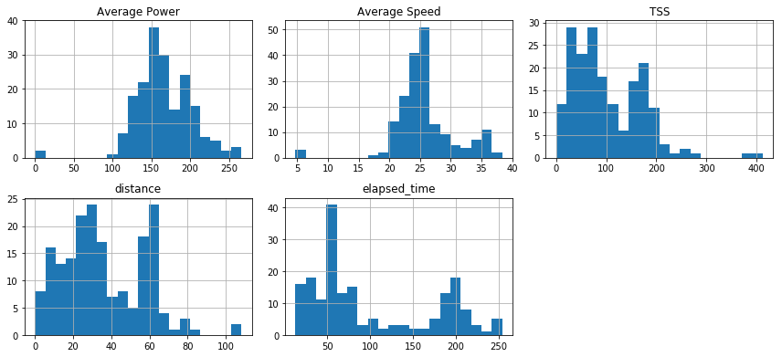

```python
key_variables.hist(normed=0, histtype='stepfilled', bins= 20, figsize=(12,8), layout=(3,3))
plt.tight_layout()
plt.show()
```

#### Exploring the relationships between variables

Exlpore the relationships between the following variables and explain any relationships you observe:

- Distance
- Moving Time
- Average Speed
- Heart Rate
- Power (watts)
- Normalised power (NP)
- Training Stress Score
- Elevation Gain

```python
#convert elevation_gain to float value
new_df['elevation_gain'] = new_df['elevation_gain'].astype(str).str.replace("m", "").astype('float64')

variables = new_df[['distance','moving_time','Average Speed','average_heartrate', 'Average Power', 'elevation_gain','NP', 'TSS']]
```

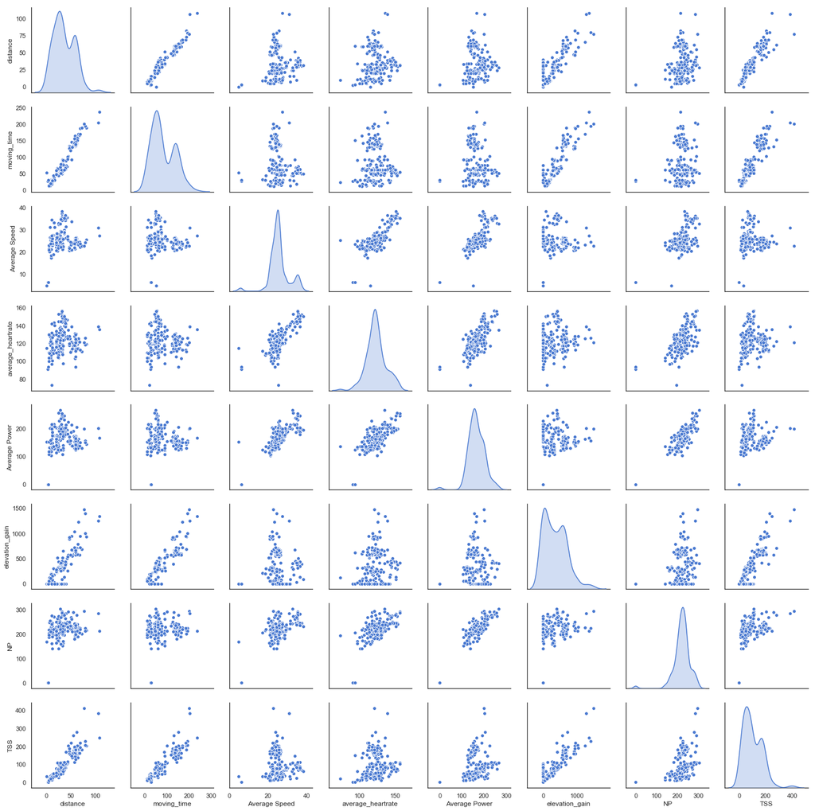

```python
sns.set(style="white", palette="muted")
sns.pairplot(variables, diag_kind = 'kde')
```

### Analyzing categories

Explore the differences between the three categories: `Race`, `Workout` and `Ride`.

- Use scatter plots with different colours for each category to explore how these categories differ.
- Use histograms or box plots to visualise the different distributions of a variable for the three categories.

```python
workout_type= new_df[['workout_type', 'distance','Average Power', 'Average Speed', 'TSS', 'elevation_gain']]
```

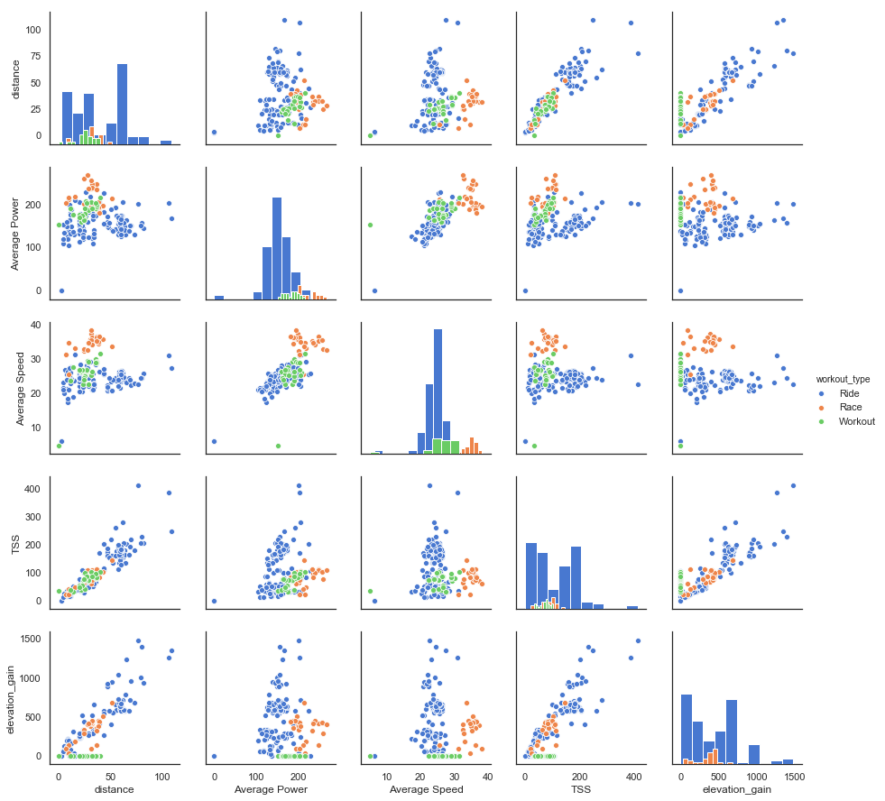

```python
sns.pairplot(data=workout_type, hue='workout_type', diag_kind = 'hist')
```

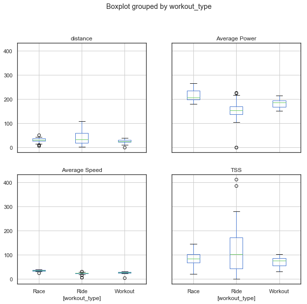

```python
boxplot = workout_type.boxplot(column=['distance', 'Average Power', 'Average Speed', 'TSS'], by=['workout_type'], figsize = (10,14), layout=(3,2))
```

Overall, the type race has consistently higher values for the variables of average speed, and power, however TSS is variable among the workout types. The boxplots demonstrate that the median value for TSS is slighty higher in the ride workout type and has a larger distribution. This can be attributed to a larger amount of 'rides' as compared to the race and workout types.

## Challenge

What leads to more kudos? Is there anything to indicate which rides are more popular? Explore the relationship between the main variables and kudos. Show a plot and comment on any relationship you observe.

```python
kudos = new_df[['elapsed_time','distance','Average Speed','Average Power','TSS', 'workout_type', 'kudos']]
kudos.head()
```

|  | elapsed_time | distance | Average Speed | Average Power | TSS | workout_type | kudos |
| --- | --- | --- | --- | --- | --- | --- | --- |
| 2018-01-27 19:39:49+00:00 | 17 | 7.6 | 26.0234 | 153.283 | 20.2257 | Ride | 4 |
| 2018-01-27 20:01:32+00:00 | 67 | 38.6 | 34.4380 | 186.599 | 94.5787 | Race | 19 |
| 2018-02-05 21:06:42+00:00 | 69 | 24.3 | 22.2417 | 163.264 | 98.3269 | Ride | 6 |
| 2018-02-07 06:59:05+00:00 | 144 | 47.1 | 20.7841 | 148.253 | 171.0780 | Ride | 10 |
| 2018-02-09 19:18:03+00:00 | 193 | 59.8 | 25.6585 | 143.918 | 147.7970 | Ride | 22 |

##### Calculate the mean of kudos for each workout type

```python
race = kudos[(kudos.workout_type == 'Race')]
race['kudos'].mean()
```

```
16.192307692307693
```

```python
ride = kudos[(kudos.workout_type == 'Ride')]
ride['kudos'].mean()
```

```
11.382352941176471
```

```python
workout = kudos[(kudos.workout_type == 'Workout')]
workout['kudos'].mean()
```

```
7.72
```

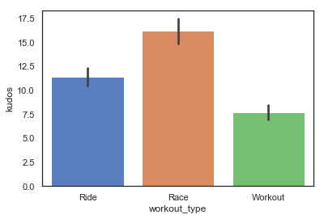

```python
#plot the data to compare the mean between each workout type
sns.barplot(x="workout_type", y='kudos', data=kudos)
```

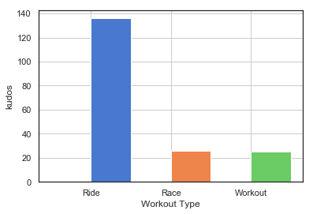

```python
ride.workout_type.hist(normed=0, histtype='stepfilled', bins=2)
race.workout_type.hist(normed=0, histtype='stepfilled', bins=2)
workout.workout_type.hist(normed=0, histtype='stepfilled',bins=2)

plt.xlabel('Workout Type')
plt.ylabel('kudos')
plt.show()
```

The workout type has a notable impact on kudos. Higher values of kudos is associated with the race workout type, with an average rating of 16.19 compared to 11.38 for rides and 7.72 for the workout type. However, from the next graph we can see that the ride workout type actually accounts for the majority of overall kudos likes. This implies that more rides leads to more kudos.

### Summary of Activity

Generate a plot that summarises the number of km ridden each month over the period of the data. Overlay this with the sum of the Training Stress Score and the average of the Average Speed to generate an overall summary of activity.

```python
#reformat dataframe usinf datetime function
new_df['date'] = pd.to_datetime(new_df['date'])
new_df.head()
```

|  | average_heartrate | average_temp | average_watts | device_watts | distance | elapsed_time | elevation_gain | kudos | moving_time | workout_type | ... | Rest AVNN | Rest SDNN | Rest rMSSD | Rest PNN50 | Rest LF | Rest HF | HRV Recovery Points | NP | IF | TSS |
| --- | --- | --- | --- | --- | --- | --- | --- | --- | --- | --- | --- | --- | --- | --- | --- | --- | --- | --- | --- | --- | --- |
| 2018-01-27 19:39:49+00:00 | 120.6 | 21.0 | 153.4 | True | 7.6 | 17 | 95.0 | 4 | 17 | Ride | ... | 0 | 0 | 0 | 0 | 0 | 0 | 0 | 222.856 | 0.83155 | 20.2257 |
| 2018-01-27 20:01:32+00:00 | 146.9 | 22.0 | 187.7 | True | 38.6 | 67 | 449.0 | 19 | 67 | Race | ... | 0 | 0 | 0 | 0 | 0 | 0 | 0 | 245.365 | 0.91554 | 94.5787 |
| 2018-02-05 21:06:42+00:00 | 119.3 | 19.0 | 165.9 | True | 24.3 | 69 | 439.0 | 6 | 65 | Ride | ... | 0 | 0 | 0 | 0 | 0 | 0 | 0 | 253.702 | 0.94665 | 98.3269 |
| 2018-02-07 06:59:05+00:00 | 124.8 | 20.0 | 151.0 | True | 47.1 | 144 | 890.0 | 10 | 134 | Ride | ... | 0 | 0 | 0 | 0 | 0 | 0 | 0 | 232.644 | 0.86808 | 171.0780 |
| 2018-02-09 19:18:03+00:00 | 123.0 | 20.0 | 145.9 | True | 59.8 | 193 | 656.0 | 22 | 139 | Ride | ... | 0 | 0 | 0 | 0 | 0 | 0 | 0 | 212.726 | 0.79375 | 147.7970 |

5 rows × 372 columns

```python
new_df.index = new_df['date']
new_df.drop('date', axis=1)
new_df.head()
```

| date | average_heartrate | average_temp | average_watts | device_watts | distance | elapsed_time | elevation_gain | kudos | moving_time | workout_type | ... | Rest AVNN | Rest SDNN | Rest rMSSD | Rest PNN50 | Rest LF | Rest HF | HRV Recovery Points | NP | IF | TSS |
| --- | --- | --- | --- | --- | --- | --- | --- | --- | --- | --- | --- | --- | --- | --- | --- | --- | --- | --- | --- | --- | --- |
| 2018-01-28 | 120.6 | 21.0 | 153.4 | True | 7.6 | 17 | 95.0 | 4 | 17 | Ride | ... | 0 | 0 | 0 | 0 | 0 | 0 | 0 | 222.856 | 0.83155 | 20.2257 |
| 2018-01-28 | 146.9 | 22.0 | 187.7 | True | 38.6 | 67 | 449.0 | 19 | 67 | Race | ... | 0 | 0 | 0 | 0 | 0 | 0 | 0 | 245.365 | 0.91554 | 94.5787 |
| 2018-02-06 | 119.3 | 19.0 | 165.9 | True | 24.3 | 69 | 439.0 | 6 | 65 | Ride | ... | 0 | 0 | 0 | 0 | 0 | 0 | 0 | 253.702 | 0.94665 | 98.3269 |
| 2018-02-07 | 124.8 | 20.0 | 151.0 | True | 47.1 | 144 | 890.0 | 10 | 134 | Ride | ... | 0 | 0 | 0 | 0 | 0 | 0 | 0 | 232.644 | 0.86808 | 171.0780 |
| 2018-02-10 | 123.0 | 20.0 | 145.9 | True | 59.8 | 193 | 656.0 | 22 | 139 | Ride | ... | 0 | 0 | 0 | 0 | 0 | 0 | 0 | 212.726 | 0.79375 | 147.7970 |

5 rows × 372 columns

```python
monthly = new_df.resample('M', on='date').sum()
monthly.head()
```

| date | average_heartrate | average_temp | average_watts | distance | elapsed_time | elevation_gain | kudos | moving_time | axPower | aPower Relative Intensity | ... | Rest AVNN | Rest SDNN | Rest rMSSD | Rest PNN50 | Rest LF | Rest HF | HRV Recovery Points | NP | IF | TSS |
| --- | --- | --- | --- | --- | --- | --- | --- | --- | --- | --- | --- | --- | --- | --- | --- | --- | --- | --- | --- | --- | --- |
| 2018-01-31 | 267.5 | 43.0 | 341.1 | 46.2 | 84 | 544.0 | 23 | 84 | 428.250 | 1.59795 | ... | 0 | 0 | 0 | 0 | 0 | 0 | 0 | 468.221 | 1.74709 | 114.8044 |
| 2018-02-28 | 1115.1 | 166.0 | 1424.6 | 343.1 | 1008 | 5193.0 | 108 | 839 | 1853.666 | 6.91666 | ... | 0 | 0 | 0 | 0 | 0 | 0 | 0 | 2036.474 | 7.59878 | 1035.4683 |
| 2018-03-31 | 1326.6 | 195.0 | 1836.2 | 456.5 | 1410 | 5073.0 | 148 | 1113 | 2277.830 | 8.49938 | ... | 0 | 0 | 0 | 0 | 0 | 0 | 0 | 2499.605 | 9.32688 | 1345.6372 |
| 2018-04-30 | 1141.4 | 171.0 | 1572.2 | 423.6 | 1198 | 5534.0 | 129 | 1002 | 1953.836 | 7.29044 | ... | 0 | 0 | 0 | 0 | 0 | 0 | 0 | 2112.524 | 7.88256 | 1232.1499 |
| 2018-05-31 | 608.7 | 50.0 | 823.7 | 174.9 | 570 | 1261.0 | 54 | 457 | 984.599 | 3.67387 | ... | 0 | 0 | 0 | 0 | 0 | 0 | 0 | 1057.498 | 3.94588 | 483.5867 |

5 rows × 367 columns

```python
#Get the average speed per month
speed = new_df.resample('M', on='date').mean()
speed['Average Speed']
```

```
date
2018-01-31    30.230700
2018-02-28    25.224933
2018-03-31    25.726055
2018-04-30    24.411667
2018-05-31    22.487580
2018-06-30    27.037100
2018-07-31    23.512267
2018-08-31    25.813550
2018-09-30    26.435125
2018-10-31    25.401967
2018-11-30    25.170179
2018-12-31    26.416408
2019-01-31    21.334839
2019-02-28    26.247547
2019-03-31    27.005531
2019-04-30    26.200181
2019-05-31    26.868062
2019-06-30    27.426943
2019-07-31    26.245400
Freq: M, Name: Average Speed, dtype: float64
```

#### Plot the activity summary

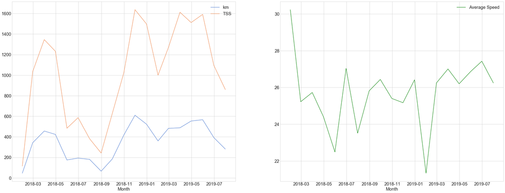

```python
plt.style.use('seaborn-whitegrid')
plt.figure(figsize=(40,15)) ## setting over-all figure size (optional)

plt.subplot(1, 2, 1)
plt.plot(monthly.index, monthly['distance'], label='km')
plt.plot(monthly.index, monthly['TSS'], label='TSS')
plt.xlabel('Month', size=20)
plt.tick_params(labelsize=20)
plt.legend(fontsize=20)

plt.subplot(1,2,2)
plt.plot(speed.index, speed['Average Speed'], label='Average Speed', color='green')
plt.xlabel('Month',size=20)
plt.tick_params(labelsize=20)
plt.legend(fontsize=20)
plt.show()
```

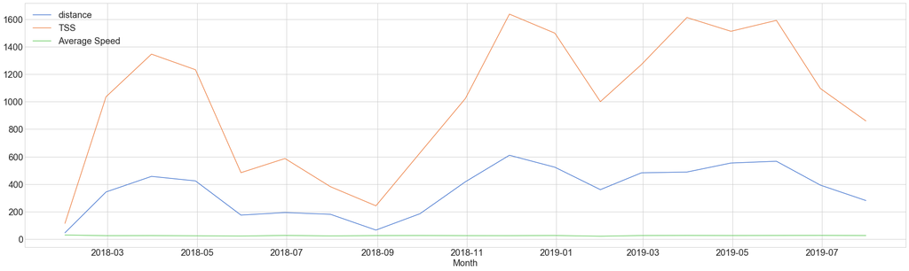

```python
plt.figure(figsize=(35,10))
plt.plot(monthly.index, monthly['distance'], label='distance')
plt.plot(monthly.index, monthly['TSS'], label='TSS')
plt.plot(speed.index, speed['Average Speed'], label='Average Speed')
plt.xlabel('Month', size=20)
plt.xticks(size=20)
plt.yticks(size=20)
plt.legend(loc='upper left', fontsize=20)
plt.show()
```

Generate a similar graph but one that shows the activity over a given month, with the sum of the values for each day of the month shown. So, if there are two rides on a given day, the graph should show the sum of the distances etc for these rides.

```python
feb = new_df[(new_df.index > '2018-02-01') & (new_df.index <= '2018-02-28')]
```

```python
#resample dataframe by day
new_feb = feb.resample('D', on='date').sum()
```

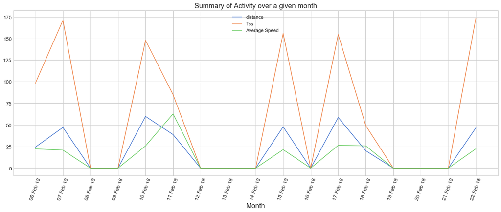

```python
plt.style.use('seaborn-whitegrid')
fig, ax = plt.subplots(figsize=(20,7))
ax.plot(new_feb.index, new_feb['distance'], label='distance')
ax.plot(new_feb.index, new_feb['TSS'], label='Tss')
ax.plot(new_feb.index, new_feb['Average Speed'], label='Average Speed')


m = mdates.DateFormatter("%d %b %y")
ax.xaxis.set_major_locator(mdates.DayLocator(interval=1))
ax.xaxis.set_major_formatter(m)
plt.xlabel('Month', size=16)
plt.xticks(rotation=70,size=12)
plt.yticks(size=12)
plt.title('Summary of Activity over a given month',size=16)
plt.legend(fontsize=11)
plt.show()
```

# Portfolio 2: Appliances energy prediction data

```python
import pandas as pd
import numpy as np
import seaborn as sns
from matplotlib import pyplot as plt
from datetime import timedelta
from datetime import datetime
import matplotlib.dates as mdates
from matplotlib.dates import DateFormatter
from sklearn import linear_model
from sklearn.linear_model import LinearRegression
from sklearn.metrics import r2_score
from sklearn.metrics import mean_squared_error
from sklearn.metrics import mean_absolute_error
from sklearn.model_selection import StratifiedKFold
from sklearn.feature_selection import RFE
from sklearn.feature_selection import RFECV
%matplotlib inline
```

```python
energy = pd.read_csv('data/energydata_complete.csv')
train = pd.read_csv('data/training.csv')
test = pd.read_csv('data/testing.csv')
```

```python
energy.head()
```

|  | date | Appliances | lights | T1 | RH_1 | T2 | RH_2 | T3 | RH_3 | T4 | ... | T9 | RH_9 | T_out | Press_mm_hg | RH_out | Windspeed | Visibility | Tdewpoint | rv1 | rv2 |
| --- | --- | --- | --- | --- | --- | --- | --- | --- | --- | --- | --- | --- | --- | --- | --- | --- | --- | --- | --- | --- | --- |
| 0 | 2016-01-11 17:00:00 | 60 | 30 | 19.89 | 47.596667 | 19.2 | 44.790000 | 19.79 | 44.730000 | 19.000000 | ... | 17.033333 | 45.53 | 6.600000 | 733.5 | 92.0 | 7.000000 | 63.000000 | 5.3 | 13.275433 | 13.275433 |
| 1 | 2016-01-11 17:10:00 | 60 | 30 | 19.89 | 46.693333 | 19.2 | 44.722500 | 19.79 | 44.790000 | 19.000000 | ... | 17.066667 | 45.56 | 6.483333 | 733.6 | 92.0 | 6.666667 | 59.166667 | 5.2 | 18.606195 | 18.606195 |
| 2 | 2016-01-11 17:20:00 | 50 | 30 | 19.89 | 46.300000 | 19.2 | 44.626667 | 19.79 | 44.933333 | 18.926667 | ... | 17.000000 | 45.50 | 6.366667 | 733.7 | 92.0 | 6.333333 | 55.333333 | 5.1 | 28.642668 | 28.642668 |
| 3 | 2016-01-11 17:30:00 | 50 | 40 | 19.89 | 46.066667 | 19.2 | 44.590000 | 19.79 | 45.000000 | 18.890000 | ... | 17.000000 | 45.40 | 6.250000 | 733.8 | 92.0 | 6.000000 | 51.500000 | 5.0 | 45.410389 | 45.410389 |
| 4 | 2016-01-11 17:40:00 | 60 | 40 | 19.89 | 46.333333 | 19.2 | 44.530000 | 19.79 | 45.000000 | 18.890000 | ... | 17.000000 | 45.40 | 6.133333 | 733.9 | 92.0 | 5.666667 | 47.666667 | 4.9 | 10.084097 | 10.084097 |

5 rows × 29 columns

```python
df = energy[['date','Appliances']]
df.head()
```

|  | date | Appliances |
| --- | --- | --- |
| 0 | 2016-01-11 17:00:00 | 60 |
| 1 | 2016-01-11 17:10:00 | 60 |
| 2 | 2016-01-11 17:20:00 | 50 |
| 3 | 2016-01-11 17:30:00 | 50 |
| 4 | 2016-01-11 17:40:00 | 60 |

```python
df['date'] = pd.to_datetime(df['date'])
df.index = df['date']
df = df.drop('date', 1)
```

```python
new_df = df[(df.index > '2016-01-10') & (df.index <= '2016-01-18 12:00:00')]
```

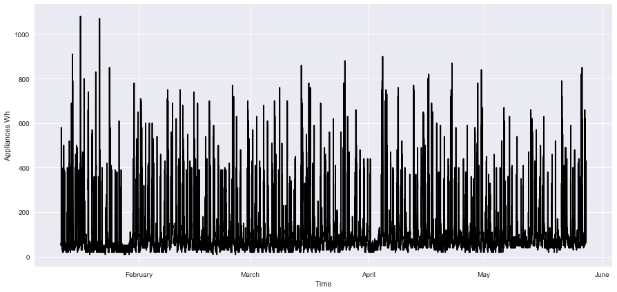

```python
fig, ax = plt.subplots(figsize=(15,7))
ax.plot(df.index, df['Appliances'], color='black')
m = mdates.DateFormatter("%B")
ax.xaxis.set_major_locator(mdates.MonthLocator(interval=1))
ax.xaxis.set_major_formatter(m)
plt.ylabel('Appliances Wh')
plt.xlabel('Time')
plt.show()
```

Energy consumption of appliances over the total time period of the data.

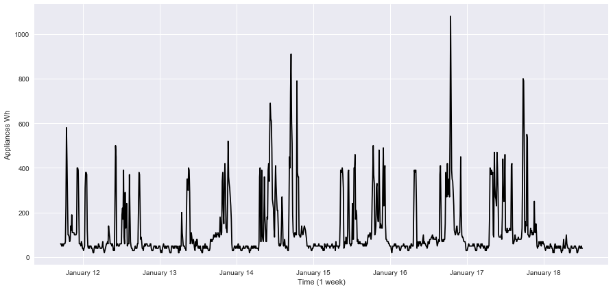

```python
fig, ax = plt.subplots(figsize=(15,7))
ax.plot(new_df.index, new_df['Appliances'], color='black')

m = mdates.DateFormatter("%B %d")
ax.xaxis.set_major_locator(mdates.DayLocator(interval=1))
ax.xaxis.set_major_formatter(m)
plt.ylabel('Appliances Wh')
plt.xlabel('Time (1 week)')
plt.show()
```

Energy consumption of appliances for the first week of data.

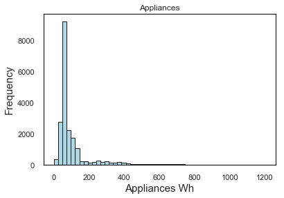

```python
energy.hist(column='Appliances', bins=50,range=(0,1200), grid=False,color='lightblue', edgecolor='k')
plt.xlabel("Appliances Wh", fontsize=15)
plt.ylabel("Frequency",fontsize=15)
plt.show()
```

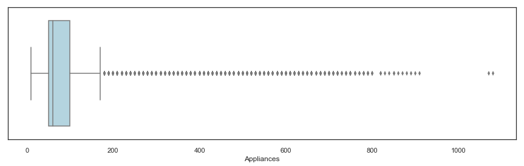

```python
sns.set(style="white", palette="husl")
plt.figure(figsize=(15,4))
b = sns.boxplot(x='Appliances', data=energy, color='lightblue')
```

Energy consumption of appliances distribution - over the total period.

Top: Histogram shows the frequecy of energy consumption.

Bottom: Boxpot shows a number of outliers and that the median is more dispersed.

```python
key_variables = energy[['Appliances', 'lights', 'T1', 'RH_1', 'T2', 'RH_2', 'T3', 'RH_3']]
key_variables.head()
```

|  | Appliances | lights | T1 | RH_1 | T2 | RH_2 | T3 | RH_3 |
| --- | --- | --- | --- | --- | --- | --- | --- | --- |
| 0 | 60 | 30 | 19.89 | 47.596667 | 19.2 | 44.790000 | 19.79 | 44.730000 |
| 1 | 60 | 30 | 19.89 | 46.693333 | 19.2 | 44.722500 | 19.79 | 44.790000 |
| 2 | 50 | 30 | 19.89 | 46.300000 | 19.2 | 44.626667 | 19.79 | 44.933333 |
| 3 | 50 | 40 | 19.89 | 46.066667 | 19.2 | 44.590000 | 19.79 | 45.000000 |
| 4 | 60 | 40 | 19.89 | 46.333333 | 19.2 | 44.530000 | 19.79 | 45.000000 |

### Correlation Matrix

```python
key_variables.corr()
```

|  | Appliances | lights | T1 | RH_1 | T2 | RH_2 | T3 | RH_3 |
| --- | --- | --- | --- | --- | --- | --- | --- | --- |
| Appliances | 1.000000 | 0.197278 | 0.055447 | 0.086031 | 0.120073 | -0.060465 | 0.085060 | 0.036292 |
| lights | 0.197278 | 1.000000 | -0.023528 | 0.106968 | -0.005622 | 0.050985 | -0.097393 | 0.131161 |
| T1 | 0.055447 | -0.023528 | 1.000000 | 0.164006 | 0.836834 | -0.002509 | 0.892402 | -0.028550 |
| RH_1 | 0.086031 | 0.106968 | 0.164006 | 1.000000 | 0.269839 | 0.797535 | 0.253230 | 0.844677 |
| T2 | 0.120073 | -0.005622 | 0.836834 | 0.269839 | 1.000000 | -0.165610 | 0.735245 | 0.121497 |
| RH_2 | -0.060465 | 0.050985 | -0.002509 | 0.797535 | -0.165610 | 1.000000 | 0.137319 | 0.678326 |
| T3 | 0.085060 | -0.097393 | 0.892402 | 0.253230 | 0.735245 | 0.137319 | 1.000000 | -0.011234 |
| RH_3 | 0.036292 | 0.131161 | -0.028550 | 0.844677 | 0.121497 | 0.678326 | -0.011234 | 1.000000 |

```python
#Function to calculate correlation coefficient between the key varibles
def correlation(x, y, **kwargs):

    coef = np.corrcoef(x, y)[0][1]
    #Display result as string and round to 2 decimal places
    label = str(round(coef,2))

    # Add label to plot
    axis = plt.gca()
    axis.annotate(label, xy = (0.20, 0.50), size = 50, xycoords = axis.transAxes)
```

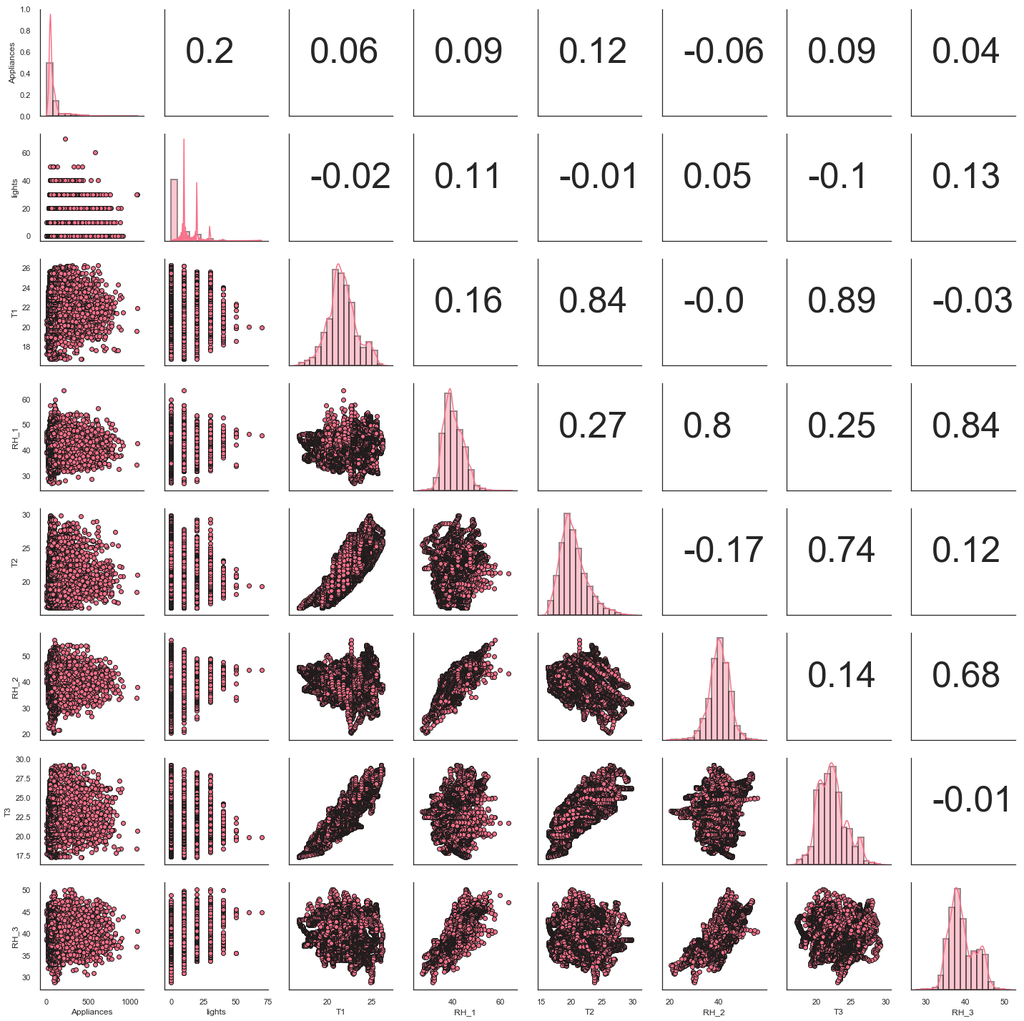

```python
sns.set(style="white", palette="husl")
g = sns.PairGrid(key_variables, diag_sharey=False)
g = g.map_diag(sns.distplot, bins=15, hist=True,hist_kws={"linewidth": 2,"edgecolor":'black'})
g = g.map_lower(plt.scatter,edgecolor = 'k')
g = g.map_upper(correlation)
```

Pair plot using sns PairGrid to generate a similar graph as displayed in Figure 9 of the paper.

The plot displays the relationship between the energy consumption variables of Appliances with lights, T1, RH1, T2, RH2, T3, RH3. T1 and RH1.

### Formatting the energy dataframe

```python
#Add the weekday index
df['weekday'] = df.index.weekday
df.head()
```

| date | Appliances | weekday |
| --- | --- | --- |
| 2016-01-11 17:00:00 | 60 | 0 |
| 2016-01-11 17:10:00 | 60 | 0 |
| 2016-01-11 17:20:00 | 50 | 0 |
| 2016-01-11 17:30:00 | 50 | 0 |
| 2016-01-11 17:40:00 | 60 | 0 |

```python
#add a new column where weekday value corresponds to the day
days = {0:'Mon',1:'Tues',2:'Wed',3:'Thurs',4:'Fri',5:'Sat',6:'Sun'}
df['day_of_week'] = df['weekday'].apply(lambda x: days[x])
df.head()
```

| date | Appliances | weekday | day_of_week |
| --- | --- | --- | --- |
| 2016-01-11 17:00:00 | 60 | 0 | Mon |
| 2016-01-11 17:10:00 | 60 | 0 | Mon |
| 2016-01-11 17:20:00 | 50 | 0 | Mon |
| 2016-01-11 17:30:00 | 50 | 0 | Mon |
| 2016-01-11 17:40:00 | 60 | 0 | Mon |

```python
#Adapted from https://stackoverflow.com/questions/57577805/my-non-numeric-columns-are-deleted-on-resample
num = df.select_dtypes('int64').columns
non_num = df.columns.difference(num)
d = {**{x: 'sum' for x in num}, **{x: 'first' for x in non_num}}

#resample the data to get the sum of appliance usage for each hour of the day, while keeping the non-numerical data
df = df.resample('H').agg(d)
df.head()
```

| date | Appliances | weekday | day_of_week |
| --- | --- | --- | --- |
| 2016-01-11 17:00:00 | 330 | 0 | Mon |
| 2016-01-11 18:00:00 | 1060 | 0 | Mon |
| 2016-01-11 19:00:00 | 1040 | 0 | Mon |
| 2016-01-11 20:00:00 | 750 | 0 | Mon |
| 2016-01-11 21:00:00 | 620 | 0 | Mon |

```python
#Convert days of week into category data type and order from Sunday to Saturday
df['day_of_week'] = pd.Categorical(df['day_of_week'], categories=
    ["Sun","Mon", "Tues", "Wed", "Thurs", "Fri","Sat"],
    ordered=True)
```

#### This section will include the creation of 4 new data frames from 'df' to plot 4 consecutive weeks of data in a heatmap.

```python
#Week 1
df1 = df['2016-01-17':'2016-01-23']
#Week 2
df2 = df['2016-01-24':'2016-01-30']
#Week 3
df3 = df['2016-01-31':'2016-02-06']
#Week 4
df4 = df['2016-02-07':'2016-02-13']
```

```python
#Pivot table by day_of_week column
df1 = pd.pivot_table(df1, index=df1.index.hour, columns=['day_of_week'], values="Appliances")
df1.head()
```

| day_of_week date | Sun | Mon | Tues | Wed | Thurs | Fri | Sat |
| --- | --- | --- | --- | --- | --- | --- | --- |
| 0 | 280 | 270 | 280 | 220 | 250 | 240 | 260 |
| 1 | 310 | 260 | 270 | 270 | 330 | 220 | 190 |
| 2 | 260 | 260 | 200 | 190 | 250 | 230 | 210 |
| 3 | 300 | 250 | 280 | 260 | 300 | 240 | 230 |
| 4 | 310 | 270 | 200 | 250 | 240 | 220 | 180 |

```python
df2 = pd.pivot_table(df2, index=df2.index.hour, columns=['day_of_week'], values="Appliances")
df2.head()
```

| day_of_week date | Sun | Mon | Tues | Wed | Thurs | Fri | Sat |
| --- | --- | --- | --- | --- | --- | --- | --- |
| 0 | 210 | 290 | 1180 | 270 | 260 | 200 | 260 |
| 1 | 260 | 290 | 260 | 210 | 180 | 260 | 200 |
| 2 | 190 | 250 | 270 | 240 | 250 | 250 | 270 |
| 3 | 270 | 290 | 210 | 190 | 250 | 180 | 220 |
| 4 | 190 | 230 | 290 | 250 | 200 | 240 | 210 |

```python
df3 = pd.pivot_table(df3, index=df3.index.hour, columns=['day_of_week'], values="Appliances")
df3.head()
```

| day_of_week date | Sun | Mon | Tues | Wed | Thurs | Fri | Sat |
| --- | --- | --- | --- | --- | --- | --- | --- |
| 0 | 280 | 270 | 370 | 360 | 230 | 220 | 290 |
| 1 | 210 | 280 | 300 | 390 | 270 | 260 | 280 |
| 2 | 270 | 230 | 270 | 390 | 280 | 290 | 270 |
| 3 | 280 | 290 | 280 | 290 | 190 | 260 | 270 |
| 4 | 220 | 270 | 270 | 360 | 280 | 210 | 220 |

```python
df4 = pd.pivot_table(df4, index=df4.index.hour, columns=['day_of_week'], values="Appliances")
df4.head()
```

| day_of_week date | Sun | Mon | Tues | Wed | Thurs | Fri | Sat |
| --- | --- | --- | --- | --- | --- | --- | --- |
| 0 | 230 | 280 | 280 | 420 | 270 | 400 | 380 |
| 1 | 260 | 280 | 290 | 430 | 320 | 260 | 320 |
| 2 | 270 | 270 | 250 | 400 | 320 | 330 | 240 |
| 3 | 260 | 280 | 220 | 410 | 260 | 330 | 310 |
| 4 | 270 | 270 | 280 | 400 | 280 | 340 | 290 |

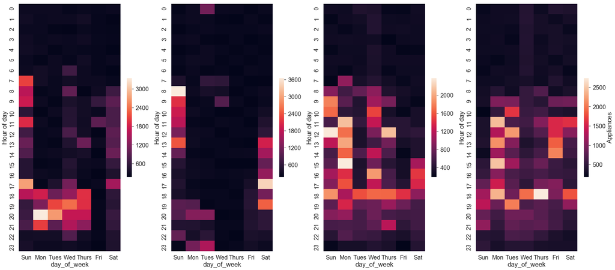

```python
fig = plt.figure(figsize = (35,70))
ax1 = fig.add_subplot(4, 4, 1) # row, column, position (4 row, 4 col)
ax2 = fig.add_subplot(4, 4, 2)
ax3 = fig.add_subplot(4, 4, 3)
ax4 = fig.add_subplot(4, 4, 4)

# Use ax parameter to indicate which subplot to use for each plot
sns.heatmap(df1, ax=ax1, cbar_kws={'shrink': .4})
sns.heatmap(df2, ax=ax2, cbar_kws={'shrink': .4})
sns.heatmap(df3, ax=ax3, cbar_kws={'shrink': .4})
sns.heatmap(df4, ax=ax4, cbar_kws={'label': 'Appliances','shrink': .4})
ax1.set_ylabel('Hour of day')
ax2.set_ylabel('Hour of day')
ax3.set_ylabel('Hour of day')
ax4.set_ylabel('Hour of day')
sns.set(font_scale=2)
```

The heatmap does not show any clear pattern in regards to the day of the week for energy consumption. There is no specific day in which energy consumption is higher than another. This was also concluded in the paper.

### Performance of Linear regression model

```python
train.shape
```

```
(14803, 32)
```

```python
test.shape
```

```
(4932, 32)
```

```python
train.columns
```

```
Index(['date', 'Appliances', 'lights', 'T1', 'RH_1', 'T2', 'RH_2', 'T3',
       'RH_3', 'T4', 'RH_4', 'T5', 'RH_5', 'T6', 'RH_6', 'T7', 'RH_7', 'T8',
       'RH_8', 'T9', 'RH_9', 'T_out', 'Press_mm_hg', 'RH_out', 'Windspeed',
       'Visibility', 'Tdewpoint', 'rv1', 'rv2', 'NSM', 'WeekStatus',
       'Day_of_week'],
      dtype='object')
```

```python
x_train= train.drop(['Appliances', 'date','WeekStatus', 'Day_of_week' ], axis=1)
y_train = train['Appliances']

x_test = test.drop(['Appliances','date','WeekStatus', 'Day_of_week'], axis=1)
y_test = test['Appliances']

print('X_train shape:',x_train.shape )
print('Y_train shape:',y_train.shape )
print('X_test shape:',x_test.shape )
print('Y_test shape:',y_test.shape )
```

```
X_train shape: (14803, 28)
Y_train shape: (14803,)
X_test shape: (4932, 28)
Y_test shape: (4932,)
```

The training and testing data frames contain columns with non-numerical values including date, WeekStatus and Day_of_week. These values have been dropped above leaving 28 columns in the dataframes. As mentioned in the paper, the RFE algorithm and the linear model requires the variables to be of numerical value and are therefore cast as dummy variables. The next steps replicate the same bevahoiur, casting the non-numerical data to dummy values.

```python
#Use the funtion get-dummies for each day of the week
day_week = train['Day_of_week']
day_w = pd.get_dummies(day_week)

day_w.head()
```

|  | Friday | Monday | Saturday | Sunday | Thursday | Tuesday | Wednesday |
| --- | --- | --- | --- | --- | --- | --- | --- |
| 0 | 0 | 1 | 0 | 0 | 0 | 0 | 0 |
| 1 | 0 | 1 | 0 | 0 | 0 | 0 | 0 |
| 2 | 0 | 1 | 0 | 0 | 0 | 0 | 0 |
| 3 | 0 | 1 | 0 | 0 | 0 | 0 | 0 |
| 4 | 0 | 1 | 0 | 0 | 0 | 0 | 0 |

```python
#join the new values to the train dataframe
x_train = train.join(day_w)
x_train.shape
```

```
(14803, 39)
```

```python
x_train.columns
```

```
Index(['date', 'Appliances', 'lights', 'T1', 'RH_1', 'T2', 'RH_2', 'T3',
       'RH_3', 'T4', 'RH_4', 'T5', 'RH_5', 'T6', 'RH_6', 'T7', 'RH_7', 'T8',
       'RH_8', 'T9', 'RH_9', 'T_out', 'Press_mm_hg', 'RH_out', 'Windspeed',
       'Visibility', 'Tdewpoint', 'rv1', 'rv2', 'NSM', 'WeekStatus',
       'Day_of_week', 'Friday', 'Monday', 'Saturday', 'Sunday', 'Thursday',
       'Tuesday', 'Wednesday'],
      dtype='object')
```

```python
x_new = pd.DataFrame()
for col in x_train.columns:
    x_new[col] = x_train[col]
print(x_new.shape)
```

```
(14803, 39)
```

```python
#Do the same for the testing df
day_week_t = test['Day_of_week']
day_w_t = pd.get_dummies(day_week_t)

day_w_t.head()
```

|  | Friday | Monday | Saturday | Sunday | Thursday | Tuesday | Wednesday |
| --- | --- | --- | --- | --- | --- | --- | --- |
| 0 | 0 | 1 | 0 | 0 | 0 | 0 | 0 |
| 1 | 0 | 1 | 0 | 0 | 0 | 0 | 0 |
| 2 | 0 | 1 | 0 | 0 | 0 | 0 | 0 |
| 3 | 0 | 1 | 0 | 0 | 0 | 0 | 0 |
| 4 | 0 | 1 | 0 | 0 | 0 | 0 | 0 |

```python
#join the values to the test dataframe
x_test = test.join(day_w_t)
x_test.shape
```

```
(4932, 39)
```

```python
x_test.columns
```

```
Index(['date', 'Appliances', 'lights', 'T1', 'RH_1', 'T2', 'RH_2', 'T3',
       'RH_3', 'T4', 'RH_4', 'T5', 'RH_5', 'T6', 'RH_6', 'T7', 'RH_7', 'T8',
       'RH_8', 'T9', 'RH_9', 'T_out', 'Press_mm_hg', 'RH_out', 'Windspeed',
       'Visibility', 'Tdewpoint', 'rv1', 'rv2', 'NSM', 'WeekStatus',
       'Day_of_week', 'Friday', 'Monday', 'Saturday', 'Sunday', 'Thursday',
       'Tuesday', 'Wednesday'],
      dtype='object')
```

```python
new_test = pd.DataFrame()
for col in x_test.columns:
    new_test[col] = x_test[col]
print(new_test.shape)
```

```
(4932, 39)
```

```python
x_train = x_new.drop(['Appliances', 'date','WeekStatus', 'Day_of_week' ], axis=1) #drop the non-numerical values
y_train = x_new['Appliances']

x_test = new_test.drop(['Appliances','date','WeekStatus', 'Day_of_week'], axis=1)
y_test = new_test['Appliances']

print('X_train shape:',x_train.shape )
print('Y_train shape:',y_train.shape )
print('X_test shape:',x_test.shape )
print('Y_test shape:',y_test.shape )
```

```
X_train shape: (14803, 35)
Y_train shape: (14803,)
X_test shape: (4932, 35)
Y_test shape: (4932,)
```

After casting the non-numerical data to dummy values, joining and re-formatting the train and test dataframes, the number of predictors is now 35 which is the same amount as in the paper.

```python
#train model on the training set
model = linear_model.LinearRegression()
model.fit(x_train, y_train)
```

```
LinearRegression(copy_X=True, fit_intercept=True, n_jobs=1, normalize=False)
```

```python
#Compute MSE, RSME, R squared and MAE for training data set
y_train_p = model.predict(x_train)

mse= mean_squared_error(y_train, y_train_p)
r2 = r2_score(y_train, y_train_p)
mae = mean_absolute_error(y_train, y_train_p)
rmse = np.sqrt(mean_squared_error(y_train, y_train_p))

print('Training set metrics')
print("MSE:", mse)
print("R Squared:", r2)
print("MAE:", mae)
print("RMSE:", rmse)
```

```
Training set metrics
MSE: 8687.278741530838
R Squared: 0.17834376492372517
MAE: 53.13891233505933
RMSE: 93.20557248110671
```

```python
#Compute MSE, RSME, R squared and MAE for testing data set
y_test_pred = model.predict(x_test)

mse= mean_squared_error(y_test, y_test_pred)
r2 = r2_score(y_test, y_test_pred)
mae = mean_absolute_error(y_test, y_test_pred)
rmse = np.sqrt(mean_squared_error(y_test, y_test_pred))

print('Testing set metrics')
print("MSE:", mse)
print("R Squared:", r2)
print("MAE:", mae)
print("RMSE:", rmse)
```

```
Testing set metrics
MSE: 8681.847902503707
R Squared: 0.1590071277867222
MAE: 51.984929609388175
RMSE: 93.1764342658792
```

As demonstrated in the paper, the model is prediciting better on the training data set than the test set, however both R squared values are very low for the linear model. The linear model performs quite poorly as compared to the other models including SVM, GBM and RF which are also tested in the paper. The mean absolute error of the linear model is also higher than the MAE of the other models. This indicates that the linear model is making more errors in its prediction as compared to the three other models. The other models generate a lower RMSE and higher R2 score. Overall, the linear model is the worst performing model in the paper.

### Feature selection

Recursvie Feature estimation (RFE) removes features one by one and evaluates the model each time to find the best target number of features.

```python
#fit the linear model on the data implementing StratifiedKfold for 10 cross validated sets
model = LinearRegression()
k = StratifiedKFold(n_splits=10, random_state=42)
rfecv = RFECV(estimator=model, step=1, cv=k, scoring='r2')
rfecv = rfecv.fit(x_train, y_train)
```

```python
print('Optimal number of features :', rfecv.n_features_)
print('Best features :', x_train.columns[rfecv.support_])
```

```
Optimal number of features : 22
Best features : Index(['lights', 'T1', 'RH_1', 'T2', 'RH_2', 'T3', 'RH_3', 'T6', 'RH_7', 'T8',
       'RH_8', 'T9', 'T_out', 'Windspeed', 'Tdewpoint', 'Friday', 'Monday',
       'Saturday', 'Sunday', 'Thursday', 'Tuesday', 'Wednesday'],
      dtype='object')
```

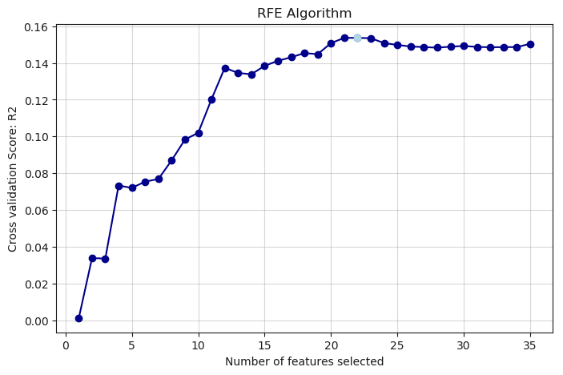

```python
# Plot number of features VS. cross-validation scores R2
#plt.style.use('seaborn')
plt.figure(figsize=(8,5))
plt.xlabel("Number of features selected")
plt.ylabel("Cross validation Score: R2")
plt.title('RFE Algorithm')

g = plt.plot(range(1, len(rfecv.grid_scores_) + 1),rfecv.grid_scores_, marker='o',color='darkblue')
plt.grid(alpha=0.5)

xvalues = g[0].get_xdata()
yvalues = g[0].get_ydata()
plt.plot(xvalues[21],yvalues[21], marker="o", color='lightblue')
plt.show()
```

```python
model_2 = LinearRegression()
k = StratifiedKFold(n_splits=10, random_state=42)
rfecv_2 = RFECV(estimator=model_2, step=1, cv=k, scoring='neg_mean_squared_error')
rfecv_2 = rfecv_2.fit(x_train, y_train)
```

```python
print('Optimal number of features :', rfecv_2.n_features_)
print('Best features :', x_train.columns[rfecv_2.support_])
```

```
Optimal number of features : 21
Best features : Index(['lights', 'T1', 'RH_1', 'T2', 'RH_2', 'T3', 'RH_3', 'T6', 'RH_7', 'T8',
       'RH_8', 'T9', 'T_out', 'Windspeed', 'Friday', 'Monday', 'Saturday',
       'Sunday', 'Thursday', 'Tuesday', 'Wednesday'],
      dtype='object')
```

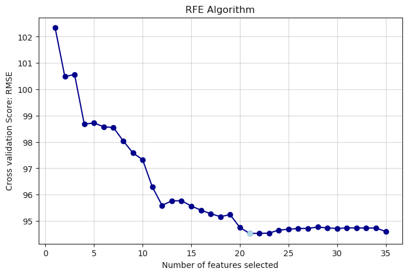

```python
# Plot number of features VS. cross-validation scores RMSE
plt.figure(figsize=(8,5))
plt.xlabel("Number of features selected")
plt.ylabel("Cross validation Score: RMSE")
plt.title('RFE Algorithm')

rmse = np.sqrt(-rfecv_2.grid_scores_)

p = plt.plot(range(1, len(rfecv_2.grid_scores_) + 1),rmse, marker='o',color='darkblue')
plt.grid(alpha=0.5)

xvals = p[0].get_xdata()
yvals = p[0].get_ydata()
plt.plot(xvals[20],yvals[21], marker="o", color='lightblue')
plt.show()
```

The above graphs demonstrate the RFE algorithm using the linear regression model with 10 cross validation sets. The results differ from the paper as the authors utitilized the random forest regression method. With the linear model we can see the number of optimal predictors varies slightly. For cross validation scoring R2 the number of optimal features is 22, whereas the scoring for RMSE is 21 features. The difference between 21 and 22 is negligible. This was also noted by the authors as they compared the difference between 34 and 35 optimal features. As previosuly stated, the linear model peforms poorly as compared to the other models.

# Portfolio 3: Clustering Visualisation

K-means clustering is one of the simplest and popular unsupervised learning algorithms. Typically, unsupervised algorithms make inferences from datasets using only input vectors without referring to known, or labelled, outcomes. This notebook illustrates the process of K-means clustering by generating some random clusters of data and then showing the iterations of the algorithm as random cluster means are updated.

First generate random data around 4 centers.

```python
import numpy as np
import pandas as pd
from matplotlib import pyplot as plt
from copy import deepcopy
import random
%matplotlib inline
```

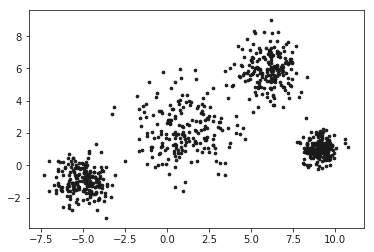

```python
center_1 = np.array([1,2])
center_2 = np.array([6,6])
center_3 = np.array([9,1])
center_4 = np.array([-5,-1])

# Generate random data and center it to the four centers each with a different variance
np.random.seed(5)
data_1 = np.random.randn(200,2) * 1.5 + center_1
data_2 = np.random.randn(200,2) * 1 + center_2
data_3 = np.random.randn(200,2) * 0.5 + center_3
data_4 = np.random.randn(200,2) * 0.8 + center_4

data = np.concatenate((data_1, data_2, data_3, data_4), axis = 0)

plt.scatter(data[:,0], data[:,1], s=7, c='k')
plt.show()
```

## 1. Generate random cluster centres

Generate four random centres.

- The number of clusters `k` is set to 4;
- Generate random centres via `centres = np.random.randn(k,c)*std + mean` where `std` and `mean` are the standard deviation and mean of the data. `c` represents the number of features in the data. Set the random seed to 6.
- Color the generated centers with `green`, `blue`, `yellow`, and `cyan`. Set the edgecolors to `red`.

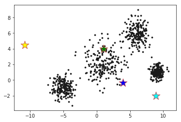

```python
# number of clusters
k = 4
c = data.shape[1]
d = data.shape[0]
# Generate random centers
np.random.seed(6)
mean = np.mean(data, axis = 0)
std = np.std(data, axis = 0)
centers = np.random.randn(k,c)*std + mean
colors =['green', 'blue', 'yellow', 'cyan']

plt.scatter(data[:,0], data[:,1], s=7, c='k')
for i in range(k):
    plt.scatter(centers[i,0], centers[i,1], s=300, marker='*', c=colors[i], edgecolor='r')
plt.show()
```

```python
print(centers)
```

```
[[  1.04092562   3.99706546]
 [  3.93329674  -0.38305685]
 [-10.83755897   4.49275315]
 [  8.89901777  -2.03761651]]
```

## 2. Visualise the clustering results in each iteration

#### Implementation of k-means clustering

The basic algorithm is:

1. start with K randomly placed cluster centroids
2. for each data point, assign it to the closest cluster centroid
3. re-estimate the cluster centroids for each cluster based on the data points that belong to it
4. if the centroid estimate has not changed significantly, stop, otherwise repeat from step 2.

Each cell will show the iterative process of step 2 and step 3 in the k-means algorithm.

For each data point we need to compute the euclidean distance from the centroids and assign it to the closest cluster centroid. Then we continue to update the cluster centers based on the mean of the data. Steps 2 and 3 are repeated until the estimate does not change significantly.

For each iteration the clusters will be plot to demonstrate how the centroids are updated.

```python
clusters = np.zeros(d) #create cluster array with shape of the data
distances = np.zeros((d,k)) #data + centroid
new_centers1 = deepcopy(centers) #copy of original centers
```

### Iteration 1

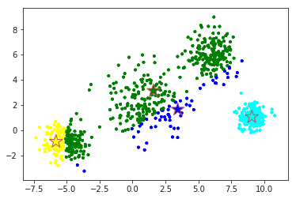

```
Centroid distance update: 8.3277619214395
```

```python
#For each data point assign to the closest centriod based on the distance
for i in range(k):
    distances[:,i] = np.linalg.norm(data - new_centers1[i], axis=1)
    #Assign data to closest centroid
    clusters = np.argmin(distances, axis = 1)

    #Calculate the mean for each cluster and then update the centroid position
for i in range(k):
    new_centers1[i] = np.mean(data[clusters == i], axis=0)

colors =['green', 'blue', 'yellow', 'cyan']

for i in range(k):
    plt.scatter(data[:, 0], data[:, 1], s=7, c=[colors[i] for i in clusters])
plt.scatter(new_centers1[:,0],new_centers1[:,1], s=300,edgecolor='r',c=['green', 'blue', 'yellow', 'cyan'], marker='*')

plt.show()

#new center distance - old center distance
print('Centroid distance update:', np.linalg.norm(new_centers1 - centers))
```

With the first iteration we can see that there is quite a big difference in distance from the old centroid position to the new centroid position.

### Iteration 2

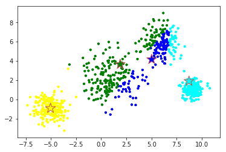

```
Centroid distance update: 3.2571049275586885
```

```python
new_centers2 = (deepcopy(new_centers1)) #copy of previous centers

for i in range(k):
    distances[:,i] = np.linalg.norm(data - new_centers2[i], axis=1)
    # Assign data to closest centroid
    clusters = np.argmin(distances, axis = 1)

    #Calculate the mean for each cluster and then update the centroid position
for i in range(k):
    new_centers2[i] = np.mean(data[clusters == i], axis=0)

for i in range(k):
    plt.scatter(data[:, 0], data[:, 1], s=7, c=[colors[i] for i in clusters])
plt.scatter(new_centers2[:,0],new_centers2[:,1], s=300,edgecolor='r',c=['green', 'blue', 'yellow', 'cyan'], marker='*')

plt.show()

#new center distance - old center distance
print('Centroid distance update:', np.linalg.norm(new_centers2 - new_centers1))
```

### Iteration 3

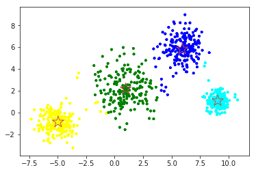

```
Centroid distance update: 2.72607644339468
```

```python
new_centers3 = (deepcopy(new_centers2)) #copy of previous centers

for i in range(k):
    distances[:,i] = np.linalg.norm(data - new_centers3[i], axis=1)
    # Assign data to closest centroid
    clusters = np.argmin(distances, axis = 1)

    #Calculate the mean for each cluster and then update the centroid position
for i in range(k):
    new_centers3[i] = np.mean(data[clusters == i], axis=0)

for i in range(k):
    plt.scatter(data[:, 0], data[:, 1], s=7, c=[colors[i] for i in clusters])
plt.scatter(new_centers3[:,0], new_centers3[:,1], s=300,edgecolor='r',c=['green', 'blue', 'yellow', 'cyan'], marker='*')

plt.show()

#new center distance - old center distance
print('Centroid distance update:', np.linalg.norm(new_centers3 - new_centers2))
```

### Iteration 4

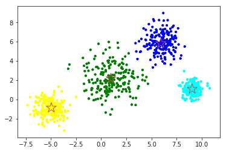

```
Centroid distance update: 0.167578908544138
```

```python
new_centers4 = (deepcopy(new_centers3)) #copy of previous centers

for i in range(k):
    distances[:,i] = np.linalg.norm(data - new_centers4[i], axis=1)
    # Assign data to closest centroid
    clusters = np.argmin(distances, axis = 1)

    #Calculate the mean for each cluster and then update the centroid position
for i in range(k):
    new_centers3[i] = np.mean(data[clusters == i], axis=0)

for i in range (k):
    plt.scatter(data[:, 0], data[:, 1], s=7, c=[colors[i] for i in clusters])
plt.scatter(new_centers4[:,0], new_centers4[:,1], s=300,edgecolor='r',c=['green', 'blue', 'yellow', 'cyan'], marker='*')

plt.show()

#new center distance - old center distance
print('Centroid distance update:',np.linalg.norm(new_centers4 - new_centers3))
```

### Iteration 5

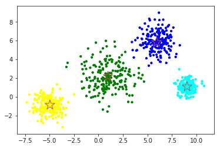

```
Centroid distance update: 0.0
```

```python
new_centers5 = (deepcopy(new_centers4)) #copy of previous centers

for i in range(k):
    distances[:,i] = np.linalg.norm(data - new_centers5[i], axis=1)
    # Assign data to closest centroid
    clusters = np.argmin(distances, axis = 1)

    #Calculate the mean for each cluster and then update the centroid position
for i in range(k):
    new_centers3[i] = np.mean(data[clusters == i], axis=0)

for i in range (k):
    plt.scatter(data[:, 0], data[:, 1], s=7, c=[colors[i] for i in clusters])
plt.scatter(new_centers5[:,0], new_centers5[:,1], s=300,edgecolor='r',c=['green', 'blue', 'yellow', 'cyan'], marker='*')

plt.show()
plt.show()

#new center distance - old center distance
print('Centroid distance update:', np.linalg.norm(new_centers5 - new_centers4))
```

By the 5th iteration, the difference between the older center and the newer center is now 0.0

The centroid has not changed since the last iteration therefore we can stop the algorithm.

**Student Number:** 44616732

**Name:** Ariana Rozsnyoi